# Group 5450-2 - Project

Carli M., Krauß J.B., Rückerl J.L.S.A., Takács B. & Tappeiner A.

May 9th, 2023

## Loading the Data

First we load the provided data-set and the packages that we will employ:

```r
# Libraries
if (!require("psych")) install.packages("psych")
if (!require("rpart")) install.packages("rpart")
if (!require("rpart.plot")) install.packages("rpart.plot")
if (!require("caret")) install.packages("caret")
if (!require("randomForest")) install.packages("randomForest")
if (!require("corrplot")) install.packages("corrplot")
library("caret")
library("rpart")
library("rpart.plot")
library("randomForest")
library("corrplot")
library("psych")

# Load data
setwd("/Users/manuel_c/Documents/00_university/01_BBE_WU/4th/data\ analytics/data_project")
hr_data <- read.csv("WA_Fn-UseC_-HR-Employee-Attrition.csv")
```

## 0 - Project Aim, Business Context & Evaluation Metric

The following project aims to build a model for the company IBM, which should be able to predict whether an employee is likely to leave the company or not, given the indicators in the existing data-set for IBM employees. Therefore, the aim is to understand the behavior of employees and identify influencing factors that make a prediction possible on whether an employee is likely to quit or not. Ultimately, the goal is to enable IBM to minimize the rate of unintended and unforeseen employee departures and to identify possibilities to improve the working environment for the employees.

The following sections examine different methods for modelling. Whether a model can be deemed good or not will be decided based on the evaluation metric “recall”. The latter is the metric of choice in this context, since false negatives have to be avoided at all costs. This is the case, since this would have the most severe implications for the company, since IBM would not have expected that an employee will leave and unexpectedly looses valuable employees, despite the model predicting that they won’t leave the company.

## 1 - Exploratory Analysis

In the following section we examine and describe the data set, the variables it contains and the properties as well as the summary statistics of the individual variables. First, we examine the structure of the data set:

```r
# Structure
str(hr_data)
```

```
## 'data.frame':    1470 obs. of  35 variables:
##  $ Age                     : int  41 49 37 33 27 32 59 30 38 36 ...
##  $ Attrition               : chr  "Yes" "No" "Yes" "No" ...
##  $ BusinessTravel          : chr  "Travel_Rarely" "Travel_Frequently" "Travel_Rarely" "Travel_Frequently" ...
##  $ DailyRate               : int  1102 279 1373 1392 591 1005 1324 1358 216 1299 ...
##  $ Department              : chr  "Sales" "Research & Development" "Research & Development" "Research & Development" ...
##  $ DistanceFromHome        : int  1 8 2 3 2 2 3 24 23 27 ...
##  $ Education               : int  2 1 2 4 1 2 3 1 3 3 ...
##  $ EducationField          : chr  "Life Sciences" "Life Sciences" "Other" "Life Sciences" ...
##  $ EmployeeCount           : int  1 1 1 1 1 1 1 1 1 1 ...
##  $ EmployeeNumber          : int  1 2 4 5 7 8 10 11 12 13 ...
##  $ EnvironmentSatisfaction : int  2 3 4 4 1 4 3 4 4 3 ...
##  $ Gender                  : chr  "Female" "Male" "Male" "Female" ...
##  $ HourlyRate              : int  94 61 92 56 40 79 81 67 44 94 ...
##  $ JobInvolvement          : int  3 2 2 3 3 3 4 3 2 3 ...
```

[output cut: 21 more lines]

```r
summary(hr_data)
```

```
##       Age         Attrition         BusinessTravel       DailyRate
##  Min.   :18.00   Length:1470        Length:1470        Min.   : 102.0
##  1st Qu.:30.00   Class :character   Class :character   1st Qu.: 465.0
##  Median :36.00   Mode  :character   Mode  :character   Median : 802.0
##  Mean   :36.92                                         Mean   : 802.5
##  3rd Qu.:43.00                                         3rd Qu.:1157.0
##  Max.   :60.00                                         Max.   :1499.0
##   Department        DistanceFromHome   Education     EducationField
##  Length:1470        Min.   : 1.000   Min.   :1.000   Length:1470
##  Class :character   1st Qu.: 2.000   1st Qu.:2.000   Class :character
##  Mode  :character   Median : 7.000   Median :3.000   Mode  :character
##                     Mean   : 9.193   Mean   :2.913
##                     3rd Qu.:14.000   3rd Qu.:4.000
##                     Max.   :29.000   Max.   :5.000
##  EmployeeCount EmployeeNumber   EnvironmentSatisfaction    Gender
##  Min.   :1     Min.   :   1.0   Min.   :1.000           Length:1470
##  1st Qu.:1     1st Qu.: 491.2   1st Qu.:2.000           Class :character
##  Median :1     Median :1020.5   Median :3.000           Mode  :character
##  Mean   :1     Mean   :1024.9   Mean   :2.722
##  3rd Qu.:1     3rd Qu.:1555.8   3rd Qu.:4.000
##  Max.   :1     Max.   :2068.0   Max.   :4.000
##    HourlyRate     JobInvolvement    JobLevel       JobRole
##  Min.   : 30.00   Min.   :1.00   Min.   :1.000   Length:1470
##  1st Qu.: 48.00   1st Qu.:2.00   1st Qu.:1.000   Class :character
##  Median : 66.00   Median :3.00   Median :2.000   Mode  :character
##  Mean   : 65.89   Mean   :2.73   Mean   :2.064
##  3rd Qu.: 83.75   3rd Qu.:3.00   3rd Qu.:3.000
##  Max.   :100.00   Max.   :4.00   Max.   :5.000
##  JobSatisfaction MaritalStatus      MonthlyIncome    MonthlyRate
##  Min.   :1.000   Length:1470        Min.   : 1009   Min.   : 2094
##  1st Qu.:2.000   Class :character   1st Qu.: 2911   1st Qu.: 8047
##  Median :3.000   Mode  :character   Median : 4919   Median :14236
##  Mean   :2.729                      Mean   : 6503   Mean   :14313
##  3rd Qu.:4.000                      3rd Qu.: 8379   3rd Qu.:20462
##  Max.   :4.000                      Max.   :19999   Max.   :26999
##  NumCompaniesWorked    Over18            OverTime         PercentSalaryHike
##  Min.   :0.000      Length:1470        Length:1470        Min.   :11.00
##  1st Qu.:1.000      Class :character   Class :character   1st Qu.:12.00
##  Median :2.000      Mode  :character   Mode  :character   Median :14.00
##  Mean   :2.693                                            Mean   :15.21
```

[output cut: 8 more lines]

```
##  Max.   :4.000     Max.   :4.000            Max.   :80    Max.   :3.0000
##  TotalWorkingYears TrainingTimesLastYear WorkLifeBalance YearsAtCompany
##  Min.   : 0.00     Min.   :0.000         Min.   :1.000   Min.   : 0.000
##  1st Qu.: 6.00     1st Qu.:2.000         1st Qu.:2.000   1st Qu.: 3.000
##  Median :10.00     Median :3.000         Median :3.000   Median : 5.000
##  Mean   :11.28     Mean   :2.799         Mean   :2.761   Mean   : 7.008
##  3rd Qu.:15.00     3rd Qu.:3.000         3rd Qu.:3.000   3rd Qu.: 9.000
##  Max.   :40.00     Max.   :6.000         Max.   :4.000   Max.   :40.000
##  YearsInCurrentRole YearsSinceLastPromotion YearsWithCurrManager
##  Min.   : 0.000     Min.   : 0.000          Min.   : 0.000
##  1st Qu.: 2.000     1st Qu.: 0.000          1st Qu.: 2.000
##  Median : 3.000     Median : 1.000          Median : 3.000
##  Mean   : 4.229     Mean   : 2.188          Mean   : 4.123
##  3rd Qu.: 7.000     3rd Qu.: 3.000          3rd Qu.: 7.000
##  Max.   :18.000     Max.   :15.000          Max.   :17.000
```

```r
# Check for Duplicates
sum(duplicated(hr_data))
```

```
## [1] 0
```

The data-set consists of 35 variables and has 1470 observations and is tidy. The summary of the data-set shows that there are no missing values in the data-set. Furthermore, there are no duplicates.

There appear to be several categorical variables. Next, we examine the different categories of the categorical variables:

```r
# Table Categorical Variables
table(hr_data$Attrition)
```

```
##
##   No  Yes
## 1233  237
```

```r
table(hr_data$BusinessTravel)
```

```
##
##        Non-Travel Travel_Frequently     Travel_Rarely
##               150               277              1043
```

```r
table(hr_data$Department)
```

```
##
##        Human Resources Research & Development                  Sales
##                     63                    961                    446
```

```r
table(hr_data$EducationField)
```

```
##
##  Human Resources    Life Sciences        Marketing          Medical
##               27              606              159              464
##            Other Technical Degree
##               82              132
```

```r
table(hr_data$Gender)
```

```
##
## Female   Male
##    588    882
```

```r
table(hr_data$MaritalStatus)
```

```
##
## Divorced  Married   Single
##      327      673      470
```

```r
table(hr_data$Over18)
```

```
##
##    Y
## 1470
```

```r
table(hr_data$OverTime)
```

```
##
##   No  Yes
## 1054  416
```

One can see that the data-set is very imbalanced in terms of our dependent variable `Attrition`. Roughly speaking, only about 16% of our observations are associated with `Attrition` being equal to “Yes”. This could be problematic for the upcoming training of our models and must be kept in mind.

For the further analysis we transform the categorical variables into factor variables in R and convert the whole data-set to a data.frame:

```r
# Convert Categorical Variables into Factor Variables
hr_data$Attrition <- factor(hr_data$Attrition)
hr_data$BusinessTravel <- factor(hr_data$BusinessTravel)
hr_data$Department <- factor(hr_data$Department)
hr_data$Education <- factor(hr_data$Education, levels = c(1, 2, 3, 4, 5), labels = c("Below College", "College", "Bachelor", "Master", "Doctor"))
hr_data$EducationField <- factor(hr_data$EducationField)
hr_data$EnvironmentSatisfaction <- factor(hr_data$EnvironmentSatisfaction, levels = c(1, 2, 3, 4), labels = c("Low", "Medium", "High", "Very High"))
hr_data$Gender <- factor(hr_data$Gender)
hr_data$JobInvolvement <- factor(hr_data$JobInvolvement, levels = c(1, 2, 3, 4), labels = c("Low", "Medium", "High", "Very High"))
hr_data$JobRole <- factor(hr_data$JobRole, levels = unique(hr_data$JobRole))
hr_data$JobSatisfaction <- factor(hr_data$JobSatisfaction, levels = c(1, 2, 3, 4), labels = c("Low", "Medium", "High", "Very High"))
hr_data$PerformanceRating <- factor(hr_data$PerformanceRating, levels = c(1, 2, 3, 4), labels = c("Low", "Good", "Excellent", "Outstanding"))
hr_data$RelationshipSatisfaction <- factor(hr_data$RelationshipSatisfaction, levels = c(1, 2, 3, 4), labels = c("Low", "Medium", "High", "Very High"))
hr_data$WorkLifeBalance <- factor(hr_data$WorkLifeBalance, levels = c(1, 2, 3, 4), labels = c("Bad", "Good", "Better", "Best"))
hr_data$MaritalStatus <- factor(hr_data$MaritalStatus)
hr_data$OverTime <- factor(hr_data$OverTime)

# Convert Dataset to Data-Frame
hr_data <- as.data.frame(hr_data)
```

Next, we drop columns, i.e. variables, that are not relevant for our analysis or don’t offer any value for predictions:

- `DailyRate` (index = 4): Daily rate charged to external customers, not relevant for our research question.
- `EmployeeCount` (index = 9): Does not offer any relevant information, since it is 1 for all the observations.
- `EmployeeNumber` (index = 10): Does not offer any relevant information,, since it only represents the ID of employee. It does not have any predictive power, and it is not needed for joining additional data sets.
- `HourlyRate` (index = 13): Hourly rate charged to external customers, not relevant for our research question.
- `MonthlyRate` (index = 20): Monthly rate charged to external customers, not relevant for our research question.
- `Over18` (index = 22): Indicates, whether an employee is older than 18. Does not offer any relevant information, since it is “Yes” for all the observations.
- `StandardHours` (index = 27): Does not offer any relevant information, since it is 80 for all the observations.

```r
# Drop columns
hr_data <- hr_data[,-c(4, 9, 10, 13, 20, 22, 27)]
```

The examination and computation of the corresponding summary statistics for the data set yield the following results:

```r
describe(hr_data, quant = c(0.25, 0.75))
```

|  | vars | n | mean | sd | median | trimmed | mad | min | max | range | skew | kurtosis | se | Q0.25 | Q0.75 |
| --- | --- | --- | --- | --- | --- | --- | --- | --- | --- | --- | --- | --- | --- | --- | --- |
| Age | 1 | 1470 | 36.9238095 | 9.1353735 | 36 | 36.471088 | 8.8956 | 18 | 60 | 42 | 0.4124432 | -0.41037755 | 2.382691e-01 | 30 | 43 |
| Attrition* | 2 | 1470 | 1.1612245 | 0.3678630 | 1 | 1.076531 | 0.0000 | 1 | 2 | 1 | 1.8406038 | 1.38876855 | 9.594613e-03 | 1 | 1 |
| BusinessTravel* | 3 | 1470 | 2.6074830 | 0.6654549 | 3 | 2.759354 | 0.0000 | 1 | 3 | 2 | -1.4360706 | 0.69119224 | 1.735641e-02 | 2 | 3 |
| Department* | 4 | 1470 | 2.2605442 | 0.5277923 | 2 | 2.254252 | 0.0000 | 1 | 3 | 2 | 0.1718795 | -0.39772752 | 1.376589e-02 | 2 | 3 |
| DistanceFromHome | 5 | 1470 | 9.1925170 | 8.1068644 | 7 | 8.084184 | 7.4130 | 1 | 29 | 28 | 0.9561635 | -0.23191820 | 2.114435e-01 | 2 | 14 |
| Education* | 6 | 1470 | 2.9129252 | 1.0241649 | 3 | 2.975340 | 1.4826 | 1 | 5 | 4 | -0.2890902 | -0.56461072 | 2.671230e-02 | 2 | 4 |
| EducationField* | 7 | 1470 | 3.2476190 | 1.3313691 | 3 | 3.095238 | 1.4826 | 1 | 6 | 5 | 0.5492486 | -0.69296354 | 3.472480e-02 | 2 | 4 |
| EnvironmentSatisfaction* | 8 | 1470 | 2.7217687 | 1.0930822 | 3 | 2.777211 | 1.4826 | 1 | 4 | 3 | -0.3209983 | -1.20495780 | 2.850980e-02 | 2 | 4 |
| Gender* | 9 | 1470 | 1.6000000 | 0.4900647 | 2 | 1.625000 | 0.0000 | 1 | 2 | 1 | -0.4078318 | -1.83492010 | 1.278188e-02 | 1 | 2 |
| JobInvolvement* | 10 | 1470 | 2.7299320 | 0.7115611 | 3 | 2.735544 | 0.0000 | 1 | 4 | 3 | -0.4974026 | 0.26155700 | 1.855896e-02 | 2 | 3 |

[output cut: 18 more lines]

Neither the beforehand conducted summary of the variables, nor the above shown description of the individual variables does suggest that outliers exist.

Next, we visually compare each variable to the dependent variable `Attrition`:

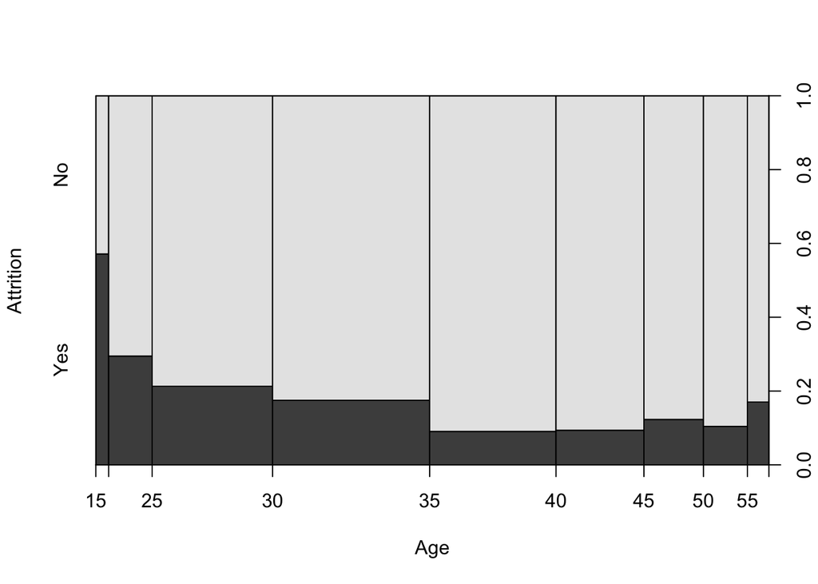

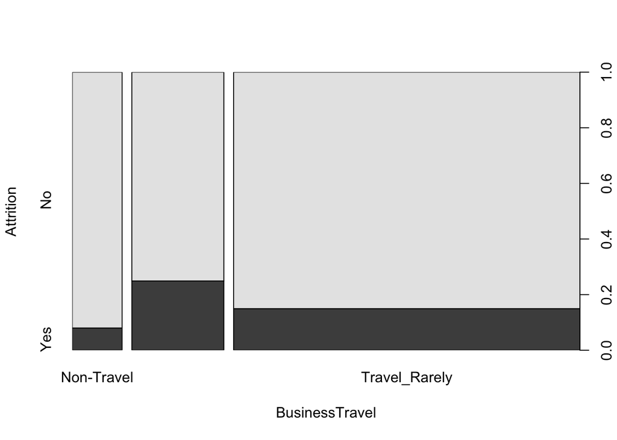

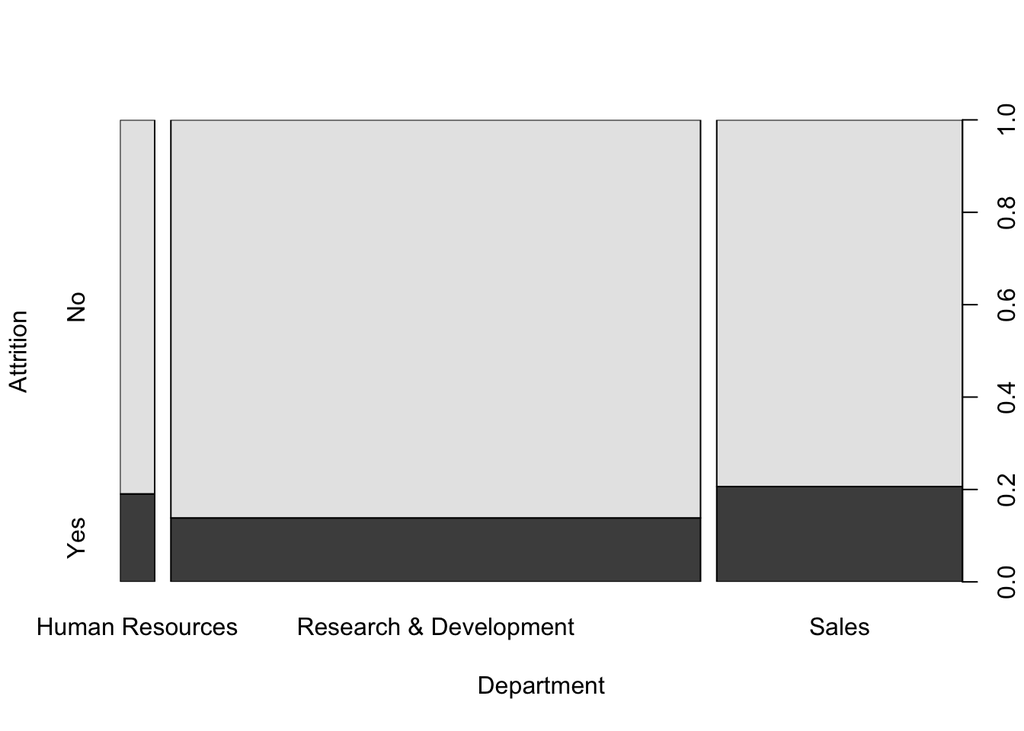

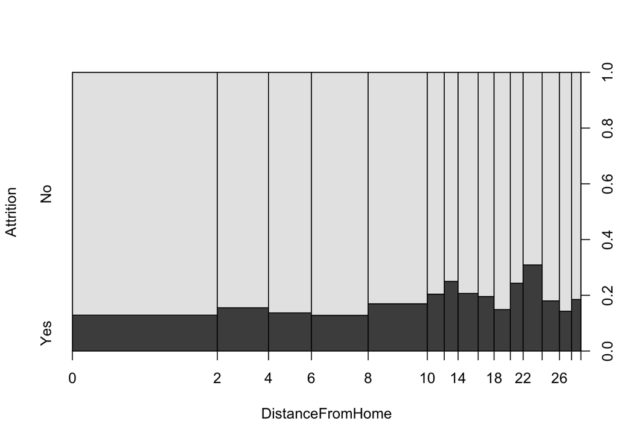

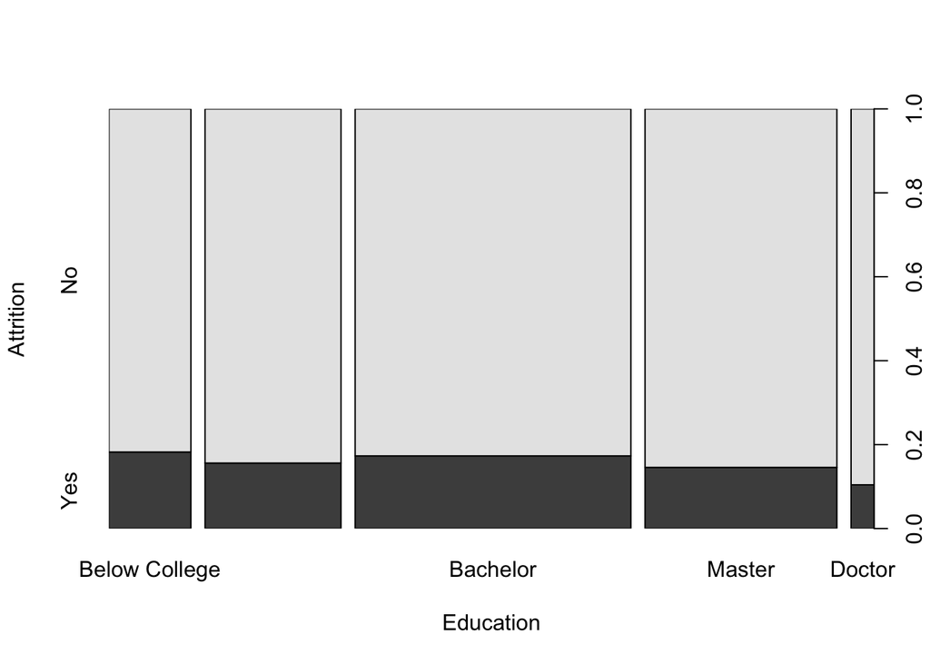

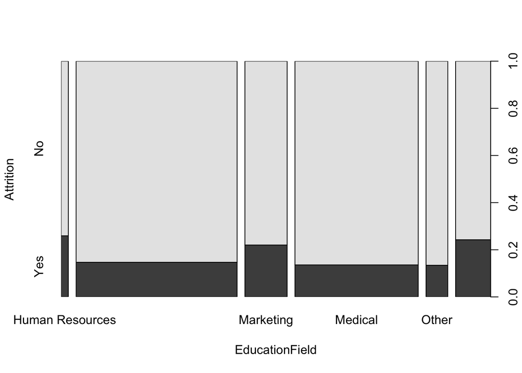

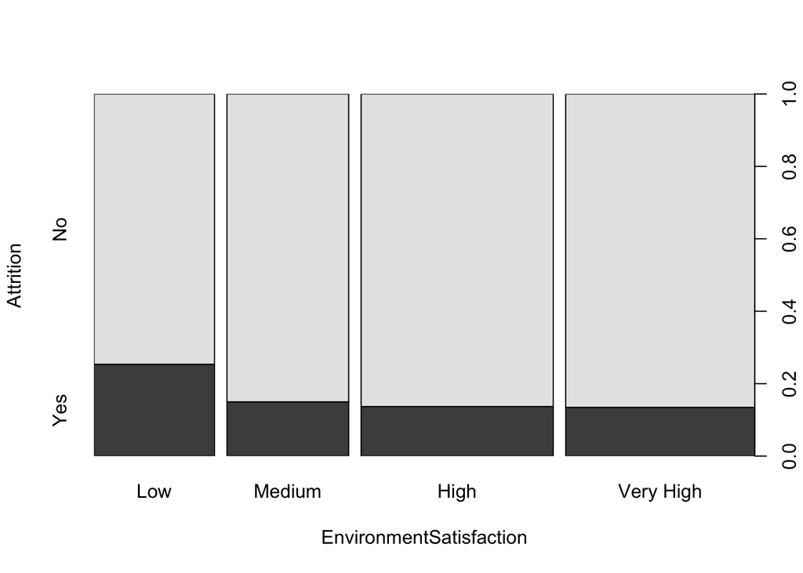

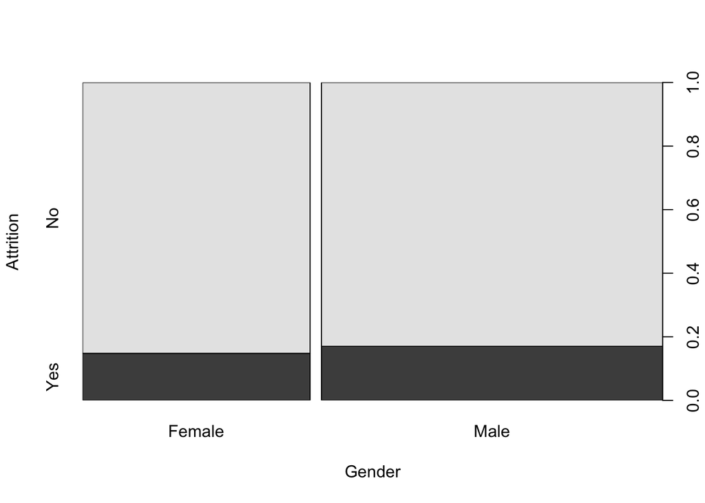

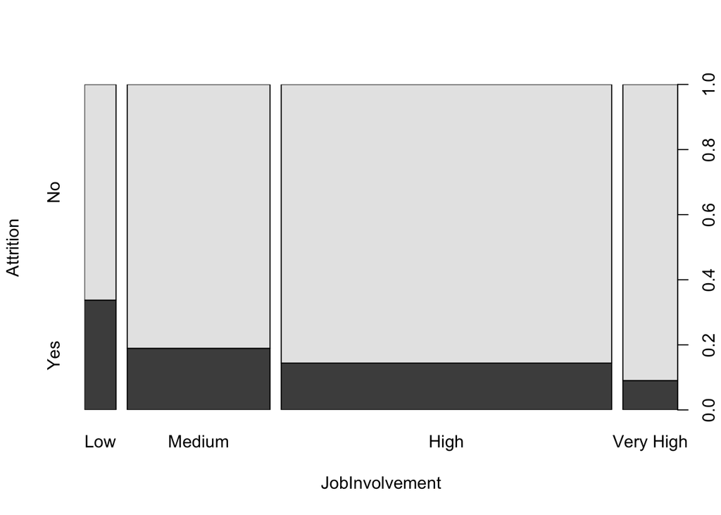

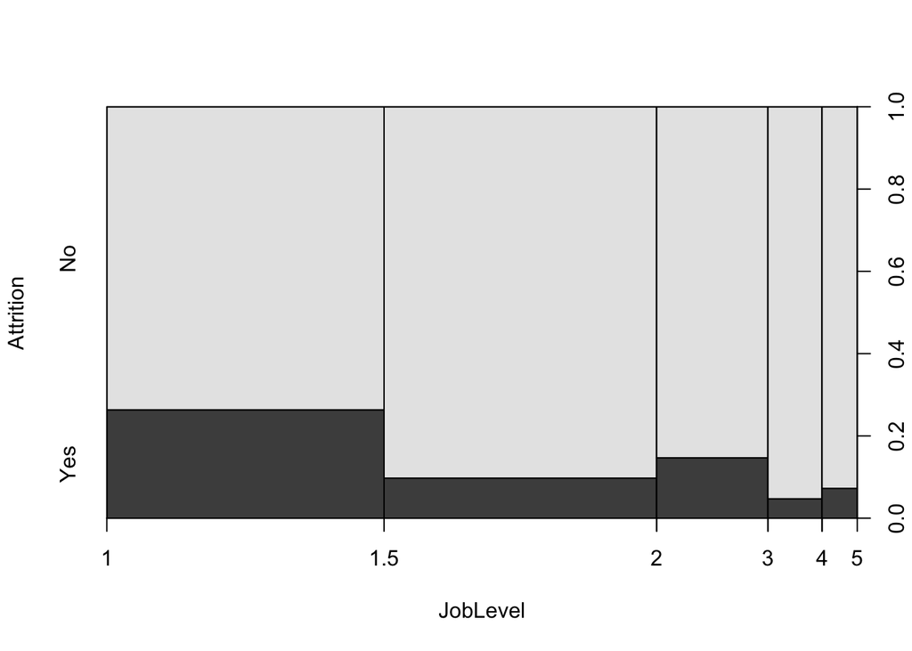

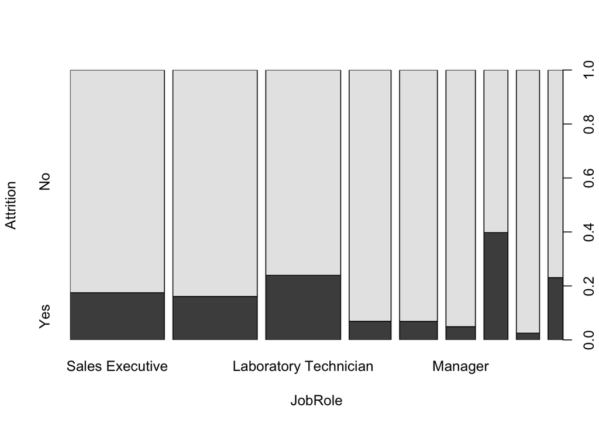

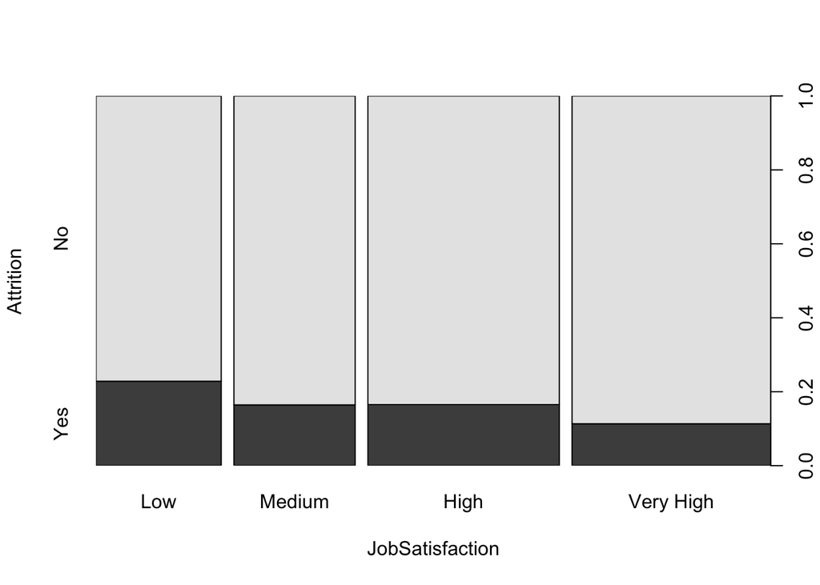

[15 more figures not shown]

```r
plot(Attrition ~ ., data = hr_data)
```

The plots suggest, that the variables `Age`, `Business Travel`, `Department`, `DistanceFromHome`, `EnvironmentSatisfaction`, `JobInvolvement`, `JobLevel`, `JobRole`, `JobSatisfaction`, `MaritalStatus`, `MonthlyIncome`, `OverTime`, `StockOptionLevel`, `TotalWorkingYears`, `YearsAtCompany` and `YearsInCurrentRole` could be important for prediction.

## 2 - Split Data

In the following step, we perform a 80/20-split of our data, based on random selection, in order to separate the data into a training set and a test set:

```r
set.seed(545002)
n <- nrow(hr_data)
n_train <- floor(n * 0.8)
id_train <- sample(1:n, n_train)
train_dat <- hr_data[id_train, ]
test_dat <- hr_data[-id_train, ]
```

Given the imbalances in our data-set we described above, we perform upsampling on the training data-set and store it separately to use if for comparison purposes.

```r
train_dat_up <- upSample(x = train_dat[, -2],
                    y = train_dat[, 2],
                 yname = "Attrition")
```

## 3 - Training Models Without Upsampling

First, we build the Naive Bayes Model:

```r
fit_nb_man <- e1071::naiveBayes(Attrition ~ ., data = train_dat)
fit_nb_man
```

```
##
## Naive Bayes Classifier for Discrete Predictors
##
## Call:
## naiveBayes.default(x = X, y = Y, laplace = laplace)
##
## A-priori probabilities:
## Y
##       No      Yes
## 0.837585 0.162415
##
## Conditional probabilities:
##      Age
## Y         [,1]     [,2]
##   No  37.64061 8.929761
##   Yes 33.74869 9.562519
##
##      BusinessTravel
## Y     Non-Travel Travel_Frequently Travel_Rarely
##   No  0.11167513        0.16142132    0.72690355
##   Yes 0.04188482        0.28795812    0.67015707
##
##      Department
## Y     Human Resources Research & Development      Sales
##   No       0.04365482             0.67918782 0.27715736
##   Yes      0.06282723             0.57068063 0.36649215
##
##      DistanceFromHome
## Y          [,1]     [,2]
##   No   8.858883 7.824250
##   Yes 10.717277 8.630037
##
##      Education
## Y     Below College    College   Bachelor     Master     Doctor
##   No     0.11573604 0.18680203 0.38781726 0.27411168 0.03553299
##   Yes    0.14136126 0.16230366 0.43455497 0.24083770 0.02094241
##
##      EducationField
## Y     Human Resources Life Sciences  Marketing    Medical      Other
##   No       0.01725888    0.42436548 0.09949239 0.32487310 0.05482234
```

[output cut: 103 more lines]

```
##
##      YearsInCurrentRole
## Y         [,1]     [,2]
##   No  4.464975 3.625654
##   Yes 2.952880 3.218839
##
##      YearsSinceLastPromotion
## Y         [,1]     [,2]
##   No  2.219289 3.215915
##   Yes 1.921466 3.162130
##
##      YearsWithCurrManager
## Y         [,1]     [,2]
##   No  4.416244 3.637449
##   Yes 2.942408 3.184144
```

```r
confusionMatrix(predict(fit_nb_man, test_dat), test_dat$Attrition, positive = "Yes")
```

```
## Confusion Matrix and Statistics
##
##           Reference
## Prediction  No Yes
##        No  194  15
##        Yes  54  31
##
##                Accuracy : 0.7653
##                  95% CI : (0.7126, 0.8126)
##     No Information Rate : 0.8435
##     P-Value [Acc > NIR] : 0.9998
##
##                   Kappa : 0.3391
##
##  Mcnemar's Test P-Value : 4.77e-06
##
##             Sensitivity : 0.6739
##             Specificity : 0.7823
##          Pos Pred Value : 0.3647
##          Neg Pred Value : 0.9282
##              Prevalence : 0.1565
##          Detection Rate : 0.1054
##    Detection Prevalence : 0.2891
##       Balanced Accuracy : 0.7281
##
##        'Positive' Class : Yes
##
```

Secondly, we build the Classification Tree model:

```r
fit_ct <- rpart(Attrition ~ ., data = train_dat)
fit_ct_f <- rpart(Attrition ~ ., data = train_dat, control = list(cp = 0))
printcp(fit_ct_f)
```

```
##
## Classification tree:
## rpart(formula = Attrition ~ ., data = train_dat, control = list(cp = 0))
##
## Variables actually used in tree construction:
##  [1] Age                      DistanceFromHome         EducationField
##  [4] EnvironmentSatisfaction  Gender                   JobRole
##  [7] JobSatisfaction          MaritalStatus            MonthlyIncome
## [10] NumCompaniesWorked       OverTime                 RelationshipSatisfaction
## [13] StockOptionLevel         TotalWorkingYears        WorkLifeBalance
##
## Root node error: 191/1176 = 0.16241
##
## n= 1176
##
##           CP nsplit rel error  xerror     xstd
## 1  0.0366492      0   1.00000 1.00000 0.066221
## 2  0.0314136      3   0.89005 0.97382 0.065514
## 3  0.0209424      4   0.85864 0.99476 0.066081
## 4  0.0183246      6   0.81675 1.03141 0.067048
## 5  0.0157068      8   0.78010 1.02618 0.066912
## 6  0.0139616      9   0.76440 1.02618 0.066912
## 7  0.0104712     13   0.70681 1.03141 0.067048
## 8  0.0091623     14   0.69634 1.04188 0.067319
## 9  0.0052356     18   0.65969 1.08377 0.068377
## 10 0.0026178     20   0.64921 1.07330 0.068116
## 11 0.0000000     22   0.64398 1.11518 0.069146
```

```r
rsq.rpart(fit_ct_f)
```

```
##
## Classification tree:
## rpart(formula = Attrition ~ ., data = train_dat, control = list(cp = 0))
##
## Variables actually used in tree construction:
##  [1] Age                      DistanceFromHome         EducationField
##  [4] EnvironmentSatisfaction  Gender                   JobRole
##  [7] JobSatisfaction          MaritalStatus            MonthlyIncome
## [10] NumCompaniesWorked       OverTime                 RelationshipSatisfaction
## [13] StockOptionLevel         TotalWorkingYears        WorkLifeBalance
##
## Root node error: 191/1176 = 0.16241
##
## n= 1176
##
##           CP nsplit rel error  xerror     xstd
## 1  0.0366492      0   1.00000 1.00000 0.066221
## 2  0.0314136      3   0.89005 0.97382 0.065514
## 3  0.0209424      4   0.85864 0.99476 0.066081
## 4  0.0183246      6   0.81675 1.03141 0.067048
## 5  0.0157068      8   0.78010 1.02618 0.066912
## 6  0.0139616      9   0.76440 1.02618 0.066912
## 7  0.0104712     13   0.70681 1.03141 0.067048
## 8  0.0091623     14   0.69634 1.04188 0.067319
## 9  0.0052356     18   0.65969 1.08377 0.068377
## 10 0.0026178     20   0.64921 1.07330 0.068116
## 11 0.0000000     22   0.64398 1.11518 0.069146
```

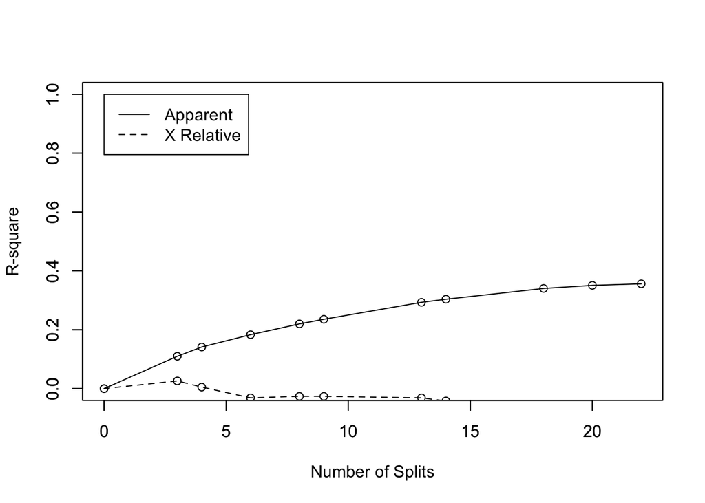

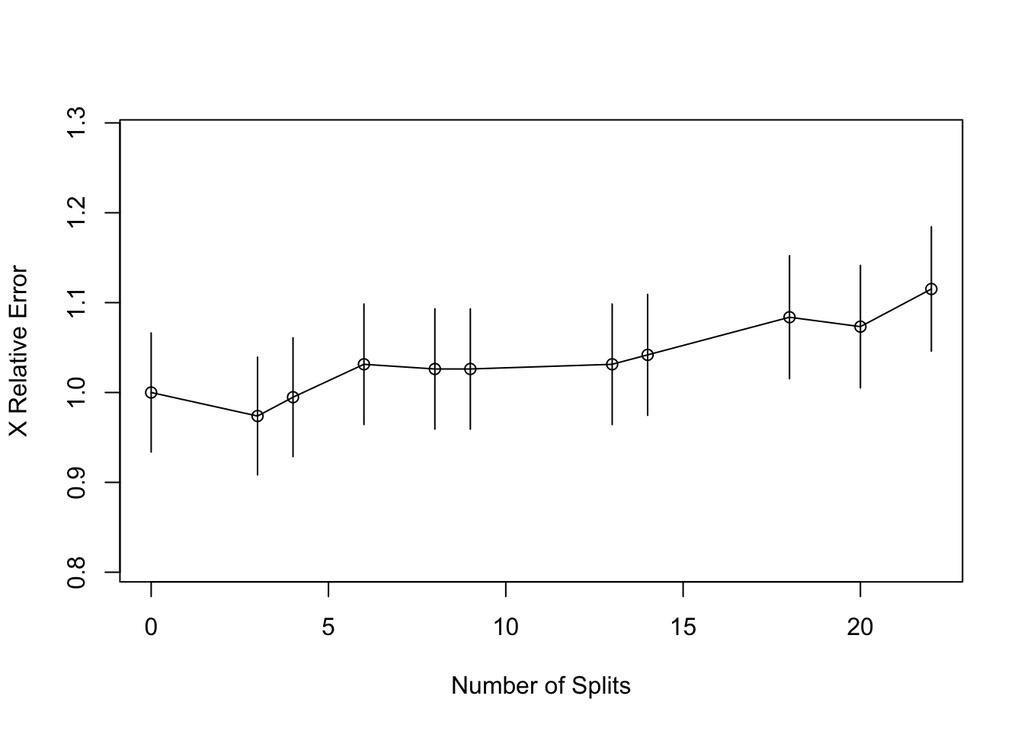

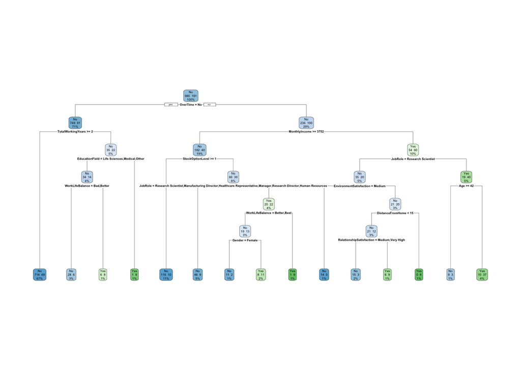

```r
rpart.plot(fit_ct, extra = 101)
```

```r
pred_ct <- factor(ifelse(predict(fit_ct, test_dat)[,2] >= 0.5, "Yes", "No"))
```

Next, we train the Logistic Regression, the knn and the Random Forest Model, based on 5-fold cross validation (*Note: We decided to hide the output of the following code chunk in order to declutter the report and improve readability.*):

```r
# Define Training Control Params
fit_control <- trainControl(method = "cv", number = 5)

# Train Logistic Regression Model With Stepwise Variable Selection
log_fit_c <- train(Attrition ~ .,
                   data = train_dat,
                   method = "glmStepAIC",
                   trControl = fit_control)

# Train knn-Model for k from 2 to 20
knn_fit <- train(Attrition ~ .,
                 data = train_dat,
                 method = "knn",
                 trControl = fit_control,
                 tuneGrid = data.frame(k = c(2,4,6,8,10,12,14,16,18,20)),
                 preProcess = c("center",  "scale"))

# Train Random Forest
mtry = round(sqrt(ncol(train_dat)-1), digits = 0)
rf_fit <- train(Attrition ~ .,
                   data = train_dat,
                   method = "rf",
                   tuneGrid = data.frame(mtry = mtry),
                   trControl = fit_control)
```

## 4 - Training Models With Upsampling

First, we build the Naive Bayes Model:

```r
fit_nb_man_up <- e1071::naiveBayes(Attrition ~ ., data = train_dat_up)
fit_nb_man_up
```

```
##
## Naive Bayes Classifier for Discrete Predictors
##
## Call:
## naiveBayes.default(x = X, y = Y, laplace = laplace)
##
## A-priori probabilities:
## Y
##  No Yes
## 0.5 0.5
##
## Conditional probabilities:
##      Age
## Y         [,1]     [,2]
##   No  37.64061 8.929761
##   Yes 33.93909 9.693805
##
##      BusinessTravel
## Y     Non-Travel Travel_Frequently Travel_Rarely
##   No  0.11167513        0.16142132    0.72690355
##   Yes 0.04365482        0.29949239    0.65685279
##
##      Department
## Y     Human Resources Research & Development      Sales
##   No       0.04365482             0.67918782 0.27715736
##   Yes      0.07005076             0.57664975 0.35329949
##
##      DistanceFromHome
## Y          [,1]     [,2]
##   No   8.858883 7.824250
##   Yes 10.977665 8.557048
##
##      Education
## Y     Below College    College   Bachelor     Master     Doctor
##   No     0.11573604 0.18680203 0.38781726 0.27411168 0.03553299
##   Yes    0.13197970 0.16142132 0.43248731 0.25177665 0.02233503
##
##      EducationField
## Y     Human Resources Life Sciences  Marketing    Medical      Other
##   No       0.01725888    0.42436548 0.09949239 0.32487310 0.05482234
```

[output cut: 103 more lines]

```
##
##      YearsInCurrentRole
## Y         [,1]     [,2]
##   No  4.464975 3.625654
##   Yes 2.992893 3.227321
##
##      YearsSinceLastPromotion
## Y         [,1]     [,2]
##   No  2.219289 3.215915
##   Yes 1.973604 3.178196
##
##      YearsWithCurrManager
## Y         [,1]     [,2]
##   No  4.416244 3.637449
##   Yes 2.967513 3.148906
```

```r
confusionMatrix(predict(fit_nb_man_up, test_dat), test_dat$Attrition, positive = "Yes")
```

```
## Confusion Matrix and Statistics
##
##           Reference
## Prediction  No Yes
##        No  135  11
##        Yes 113  35
##
##                Accuracy : 0.5782
##                  95% CI : (0.5195, 0.6353)
##     No Information Rate : 0.8435
##     P-Value [Acc > NIR] : 1
##
##                   Kappa : 0.1604
##
##  Mcnemar's Test P-Value : <2e-16
##
##             Sensitivity : 0.7609
##             Specificity : 0.5444
##          Pos Pred Value : 0.2365
##          Neg Pred Value : 0.9247
##              Prevalence : 0.1565
##          Detection Rate : 0.1190
##    Detection Prevalence : 0.5034
##       Balanced Accuracy : 0.6526
##
##        'Positive' Class : Yes
##
```

Secondly, we build the Classification Tree model:

```r
fit_ct_up <- rpart(Attrition ~ ., data = train_dat_up)

pred_ct_up <- factor(ifelse(predict(fit_ct_up, test_dat)[,2] >= 0.5, "Yes", "No"))
```

Next, we train the Logistic Regression, the knn and the Random Forest Model, based on 5-fold cross validation (*Note: We decided to hide the output of the following code chunk in order to declutter the report and improve readability.*):

```r
# Define Training Control Params
fit_control <- trainControl(method = "cv", number = 5)

# Train Logistic Regression Model With Stepwise Variable Selection
log_fit_c_up <- train(Attrition ~ .,
                   data = train_dat_up,
                   method = "glmStepAIC",
                   trControl = fit_control)

# Train knn-Model for k from 2 to 20
knn_fit_up <- train(Attrition ~ .,
                 data = train_dat_up,
                 method = "knn",
                 trControl = fit_control,
                 tuneGrid = data.frame(k = c(2,4,6,8,10,12,14,16,18,20)),
                 preProcess = c("center",  "scale"))

# Train Random Forest
mtry = round(sqrt(ncol(train_dat)-1), digits = 0)
rf_fit_up <- train(Attrition ~ .,
                   data = train_dat_up,
                   method = "rf",
                   tuneGrid = data.frame(mtry = mtry),
                   trControl = fit_control)
```

# 5 - Compare Model Performance

First, we generate the confusion matrices for the different models:

```r
# Generate Confusion Matrices Without Upsampling
cfm_logit  <- confusionMatrix(predict(log_fit_c, test_dat), test_dat$Attrition, positive = "Yes")
cfm_knn <- confusionMatrix(predict(knn_fit, test_dat), test_dat$Attrition, positive = "Yes")
cfm_nb <- confusionMatrix(predict(fit_nb_man, test_dat), test_dat$Attrition, positive = "Yes")
cfm_ct <- confusionMatrix(pred_ct, test_dat$Attrition, positive = "Yes")
cfm_rf <- confusionMatrix(predict(rf_fit, test_dat), test_dat$Attrition, positive = "Yes")

# Show Confusion Matrices Without Upsampling
cfm_logit
```

```
## Confusion Matrix and Statistics
##
##           Reference
## Prediction  No Yes
##        No  235  25
##        Yes  13  21
##
##                Accuracy : 0.8707
##                  95% CI : (0.8269, 0.9069)
##     No Information Rate : 0.8435
##     P-Value [Acc > NIR] : 0.11246
##
##                   Kappa : 0.4521
##
##  Mcnemar's Test P-Value : 0.07435
##
##             Sensitivity : 0.45652
##             Specificity : 0.94758
##          Pos Pred Value : 0.61765
##          Neg Pred Value : 0.90385
##              Prevalence : 0.15646
##          Detection Rate : 0.07143
##    Detection Prevalence : 0.11565
##       Balanced Accuracy : 0.70205
##
##        'Positive' Class : Yes
##
```

```r
cfm_knn
```

```
## Confusion Matrix and Statistics
##
##           Reference
## Prediction  No Yes
##        No  247  42
##        Yes   1   4
##
##                Accuracy : 0.8537
##                  95% CI : (0.8081, 0.8921)
##     No Information Rate : 0.8435
##     P-Value [Acc > NIR] : 0.3499
##
##                   Kappa : 0.1302
##
##  Mcnemar's Test P-Value : 1.061e-09
##
##             Sensitivity : 0.08696
##             Specificity : 0.99597
##          Pos Pred Value : 0.80000
##          Neg Pred Value : 0.85467
##              Prevalence : 0.15646
##          Detection Rate : 0.01361
##    Detection Prevalence : 0.01701
##       Balanced Accuracy : 0.54146
##
##        'Positive' Class : Yes
##
```

```r
cfm_nb
```

```
## Confusion Matrix and Statistics
##
##           Reference
## Prediction  No Yes
##        No  194  15
##        Yes  54  31
##
##                Accuracy : 0.7653
##                  95% CI : (0.7126, 0.8126)
##     No Information Rate : 0.8435
##     P-Value [Acc > NIR] : 0.9998
##
##                   Kappa : 0.3391
##
##  Mcnemar's Test P-Value : 4.77e-06
##
##             Sensitivity : 0.6739
##             Specificity : 0.7823
##          Pos Pred Value : 0.3647
##          Neg Pred Value : 0.9282
##              Prevalence : 0.1565
##          Detection Rate : 0.1054
##    Detection Prevalence : 0.2891
##       Balanced Accuracy : 0.7281
##
##        'Positive' Class : Yes
##
```

```r
cfm_ct
```

```
## Confusion Matrix and Statistics
##
##           Reference
## Prediction  No Yes
##        No  236  31
##        Yes  12  15
##
##                Accuracy : 0.8537
##                  95% CI : (0.8081, 0.8921)
##     No Information Rate : 0.8435
##     P-Value [Acc > NIR] : 0.349868
##
##                   Kappa : 0.3339
##
##  Mcnemar's Test P-Value : 0.006052
##
##             Sensitivity : 0.32609
##             Specificity : 0.95161
##          Pos Pred Value : 0.55556
##          Neg Pred Value : 0.88390
##              Prevalence : 0.15646
##          Detection Rate : 0.05102
##    Detection Prevalence : 0.09184
##       Balanced Accuracy : 0.63885
##
##        'Positive' Class : Yes
##
```

```r
cfm_rf
```

```
## Confusion Matrix and Statistics
##
##           Reference
## Prediction  No Yes
##        No  248  39
##        Yes   0   7
##
##                Accuracy : 0.8673
##                  95% CI : (0.8231, 0.9039)
##     No Information Rate : 0.8435
##     P-Value [Acc > NIR] : 0.1478
##
##                   Kappa : 0.2324
##
##  Mcnemar's Test P-Value : 1.166e-09
##
##             Sensitivity : 0.15217
##             Specificity : 1.00000
##          Pos Pred Value : 1.00000
##          Neg Pred Value : 0.86411
##              Prevalence : 0.15646
##          Detection Rate : 0.02381
##    Detection Prevalence : 0.02381
##       Balanced Accuracy : 0.57609
##
##        'Positive' Class : Yes
##
```

```r
# Generate Confusion Matrices With Upsampling
cfm_logit_up  <- confusionMatrix(predict(log_fit_c_up, test_dat), test_dat$Attrition, positive = "Yes")
cfm_knn_up <- confusionMatrix(predict(knn_fit_up, test_dat), test_dat$Attrition, positive = "Yes")
cfm_nb_up <- confusionMatrix(predict(fit_nb_man_up, test_dat), test_dat$Attrition, positive = "Yes")
cfm_ct_up <- confusionMatrix(pred_ct_up, test_dat$Attrition, positive = "Yes")
cfm_rf_up <- confusionMatrix(predict(rf_fit_up, test_dat), test_dat$Attrition, positive = "Yes")

# Show Confusion Matrices With Upsampling
cfm_logit_up
```

```
## Confusion Matrix and Statistics
##
##           Reference
## Prediction  No Yes
##        No  184  11
##        Yes  64  35
##
##                Accuracy : 0.7449
##                  95% CI : (0.691, 0.7937)
##     No Information Rate : 0.8435
##     P-Value [Acc > NIR] : 1
##
##                   Kappa : 0.3422
##
##  Mcnemar's Test P-Value : 1.92e-09
##
##             Sensitivity : 0.7609
##             Specificity : 0.7419
##          Pos Pred Value : 0.3535
##          Neg Pred Value : 0.9436
##              Prevalence : 0.1565
##          Detection Rate : 0.1190
##    Detection Prevalence : 0.3367
##       Balanced Accuracy : 0.7514
##
##        'Positive' Class : Yes
##
```

```r
cfm_knn_up
```

```
## Confusion Matrix and Statistics
##
##           Reference
## Prediction  No Yes
##        No  193  28
##        Yes  55  18
##
##                Accuracy : 0.7177
##                  95% CI : (0.6625, 0.7684)
##     No Information Rate : 0.8435
##     P-Value [Acc > NIR] : 1.000000
##
##                   Kappa : 0.1368
##
##  Mcnemar's Test P-Value : 0.004319
##
##             Sensitivity : 0.39130
##             Specificity : 0.77823
##          Pos Pred Value : 0.24658
##          Neg Pred Value : 0.87330
##              Prevalence : 0.15646
##          Detection Rate : 0.06122
##    Detection Prevalence : 0.24830
##       Balanced Accuracy : 0.58477
##
##        'Positive' Class : Yes
##
```

```r
cfm_nb_up
```

```
## Confusion Matrix and Statistics
##
##           Reference
## Prediction  No Yes
##        No  135  11
##        Yes 113  35
##
##                Accuracy : 0.5782
##                  95% CI : (0.5195, 0.6353)
##     No Information Rate : 0.8435
##     P-Value [Acc > NIR] : 1
##
##                   Kappa : 0.1604
##
##  Mcnemar's Test P-Value : <2e-16
##
##             Sensitivity : 0.7609
##             Specificity : 0.5444
##          Pos Pred Value : 0.2365
##          Neg Pred Value : 0.9247
##              Prevalence : 0.1565
##          Detection Rate : 0.1190
##    Detection Prevalence : 0.5034
##       Balanced Accuracy : 0.6526
##
##        'Positive' Class : Yes
##
```

```r
cfm_ct_up
```

```
## Confusion Matrix and Statistics
##
##           Reference
## Prediction  No Yes
##        No  198  16
##        Yes  50  30
##
##                Accuracy : 0.7755
##                  95% CI : (0.7235, 0.8219)
##     No Information Rate : 0.8435
##     P-Value [Acc > NIR] : 0.9992
##
##                   Kappa : 0.3463
##
##  Mcnemar's Test P-Value : 4.865e-05
##
##             Sensitivity : 0.6522
##             Specificity : 0.7984
##          Pos Pred Value : 0.3750
##          Neg Pred Value : 0.9252
##              Prevalence : 0.1565
##          Detection Rate : 0.1020
##    Detection Prevalence : 0.2721
##       Balanced Accuracy : 0.7253
##
##        'Positive' Class : Yes
##
```

```r
cfm_rf_up
```

```
## Confusion Matrix and Statistics
##
##           Reference
## Prediction  No Yes
##        No  245  34
##        Yes   3  12
##
##                Accuracy : 0.8741
##                  95% CI : (0.8307, 0.9098)
##     No Information Rate : 0.8435
##     P-Value [Acc > NIR] : 0.08339
##
##                   Kappa : 0.3429
##
##  Mcnemar's Test P-Value : 8.14e-07
##
##             Sensitivity : 0.26087
##             Specificity : 0.98790
##          Pos Pred Value : 0.80000
##          Neg Pred Value : 0.87814
##              Prevalence : 0.15646
##          Detection Rate : 0.04082
##    Detection Prevalence : 0.05102
##       Balanced Accuracy : 0.62439
##
##        'Positive' Class : Yes
##
```

The performance metrics for our models based on the training data without upsampling are the following:

```r
data.frame("Accuracy" = c(cfm_logit$overall["Accuracy"], cfm_knn$overall["Accuracy"],
                          cfm_nb$overall["Accuracy"], cfm_ct$overall["Accuracy"],
                          cfm_rf$overall["Accuracy"]),
           "No.Info.Rate" = c(cfm_logit$overall["AccuracyNull"], cfm_knn$overall["AccuracyNull"],
                          cfm_nb$overall["AccuracyNull"], cfm_ct$overall["AccuracyNull"],
                          cfm_rf$overall["AccuracyNull"]),
           "Recall" = c(cfm_logit$byClass["Sensitivity"], cfm_knn$byClass["Sensitivity"],
                          cfm_nb$byClass["Sensitivity"], cfm_ct$byClass["Sensitivity"],
                          cfm_rf$byClass["Sensitivity"]),
           "Precision" = c(cfm_logit$byClass["Pos Pred Value"], cfm_knn$byClass["Pos Pred Value"],
                          cfm_nb$byClass["Pos Pred Value"], cfm_ct$byClass["Pos Pred Value"],
                          cfm_rf$byClass["Pos Pred Value"]),
           row.names = c("Logistic Regression", "KNN", "Naive Bayes", "Classification Tree", "Random Forest (Class.)"))
```

|  | Accuracy | No.Info.Rate | Recall | Precision |
| --- | --- | --- | --- | --- |
| Logistic Regression | 0.8707483 | 0.8435374 | 0.45652174 | 0.6176471 |
| KNN | 0.8537415 | 0.8435374 | 0.08695652 | 0.8000000 |
| Naive Bayes | 0.7653061 | 0.8435374 | 0.67391304 | 0.3647059 |
| Classification Tree | 0.8537415 | 0.8435374 | 0.32608696 | 0.5555556 |
| Random Forest (Class.) | 0.8673469 | 0.8435374 | 0.15217391 | 1.0000000 |

The performance metrics for our models based on the training data with upsampling are the following:

```r
data.frame("Accuracy" = c(cfm_logit_up$overall["Accuracy"], cfm_knn_up$overall["Accuracy"],
                          cfm_nb_up$overall["Accuracy"], cfm_ct_up$overall["Accuracy"],
                          cfm_rf_up$overall["Accuracy"]),
           "No.Info.Rate" = c(cfm_logit_up$overall["AccuracyNull"], cfm_knn_up$overall["AccuracyNull"],
                          cfm_nb_up$overall["AccuracyNull"], cfm_ct_up$overall["AccuracyNull"],
                          cfm_rf_up$overall["AccuracyNull"]),
           "Recall" = c(cfm_logit_up$byClass["Sensitivity"], cfm_knn_up$byClass["Sensitivity"],
                          cfm_nb_up$byClass["Sensitivity"], cfm_ct_up$byClass["Sensitivity"],
                          cfm_rf_up$byClass["Sensitivity"]),
           "Precision" = c(cfm_logit_up$byClass["Pos Pred Value"], cfm_knn_up$byClass["Pos Pred Value"],
                          cfm_nb_up$byClass["Pos Pred Value"], cfm_ct_up$byClass["Pos Pred Value"],
                          cfm_rf_up$byClass["Pos Pred Value"]),
           row.names = c("Logistic Regression", "KNN", "Naive Bayes", "Classification Tree", "Random Forest (Class.)"))
```

|  | Accuracy | No.Info.Rate | Recall | Precision |
| --- | --- | --- | --- | --- |
| Logistic Regression | 0.7448980 | 0.8435374 | 0.7608696 | 0.3535354 |
| KNN | 0.7176871 | 0.8435374 | 0.3913043 | 0.2465753 |
| Naive Bayes | 0.5782313 | 0.8435374 | 0.7608696 | 0.2364865 |
| Classification Tree | 0.7755102 | 0.8435374 | 0.6521739 | 0.3750000 |
| Random Forest (Class.) | 0.8741497 | 0.8435374 | 0.2608696 | 0.8000000 |

The results show, that the imbalance of the underlying data-set is highly problematic. In our context, it is most important for the company to avoid false negatives, i.e. to avoid that the model predicts that an employee won’t leave the company although he will do so. Therefore the recall has to be used to evaluate the model performance. In terms of the recall metric only the models trained on the upsampled data seem to be considerable. Although the results are still not very good, they are considerably higher than those of the models trained on the data-set without upsampling. As the result shows, the Logistic Regression as well as the Naive Bayes model, trained on the upsampled data, provide the best results with a recall value of approximately 76%. In terms of recall they perform equally well, but regarding accuracy and precision the logistic regression model performs considerably better. Therefore, one can conclude that the logistic regression model, trained on the upsampled data, is the most promising one.

The summary of the best performing model is shown below:

```r
summary(log_fit_c_up$finalModel)
```

```
##
## Call:
## NULL
##
## Deviance Residuals:
##      Min        1Q    Median        3Q       Max
## -3.10288  -0.63409   0.03344   0.67055   3.06528
##
## Coefficients:
##                                       Estimate Std. Error z value Pr(>|z|)
## (Intercept)                         -1.159e+01  3.455e+02  -0.034 0.973242
## BusinessTravelTravel_Frequently      2.199e+00  2.974e-01   7.395 1.41e-13 ***
## BusinessTravelTravel_Rarely          1.280e+00  2.727e-01   4.693 2.69e-06 ***
## `DepartmentResearch & Development`   1.568e+01  3.455e+02   0.045 0.963803
## DepartmentSales                      1.469e+01  3.455e+02   0.043 0.966080
## DistanceFromHome                     5.299e-02  7.775e-03   6.815 9.40e-12 ***
## EducationCollege                    -4.892e-01  1.776e-01  -2.755 0.005869 **
## EducationMaster                     -2.833e-01  1.563e-01  -1.813 0.069869 .
## `EducationFieldLife Sciences`       -1.212e+00  2.209e-01  -5.488 4.07e-08 ***
## EducationFieldMarketing             -6.907e-01  3.057e-01  -2.259 0.023860 *
## EducationFieldMedical               -1.103e+00  2.242e-01  -4.918 8.76e-07 ***
## EducationFieldOther                 -1.040e+00  3.339e-01  -3.114 0.001847 **
## EnvironmentSatisfactionMedium       -1.485e+00  2.077e-01  -7.151 8.62e-13 ***
## EnvironmentSatisfactionHigh         -1.217e+00  1.858e-01  -6.550 5.77e-11 ***
## `EnvironmentSatisfactionVery High`  -1.749e+00  1.960e-01  -8.921  < 2e-16 ***
## GenderMale                           4.773e-01  1.331e-01   3.586 0.000336 ***
## JobInvolvementMedium                -1.230e+00  2.847e-01  -4.322 1.55e-05 ***
## JobInvolvementHigh                  -1.432e+00  2.686e-01  -5.330 9.82e-08 ***
## `JobInvolvementVery High`           -2.201e+00  3.398e-01  -6.476 9.41e-11 ***
## JobLevel                             7.388e-01  2.315e-01   3.191 0.001416 **
## `JobRoleResearch Scientist`         -1.035e+00  1.906e-01  -5.427 5.73e-08 ***
## `JobRoleManufacturing Director`     -9.583e-01  2.952e-01  -3.246 0.001170 **
## `JobRoleHealthcare Representative`  -2.256e+00  3.485e-01  -6.472 9.68e-11 ***
## JobRoleManager                      -1.243e+00  5.428e-01  -2.291 0.021987 *
## `JobRoleSales Representative`        1.764e+00  3.167e-01   5.571 2.54e-08 ***
## `JobRoleResearch Director`          -2.351e+00  6.466e-01  -3.635 0.000278 ***
## `JobRoleHuman Resources`             1.559e+01  3.455e+02   0.045 0.964000
## JobSatisfactionMedium               -8.902e-01  1.963e-01  -4.536 5.73e-06 ***
## JobSatisfactionHigh                 -1.003e+00  1.769e-01  -5.668 1.45e-08 ***
## `JobSatisfactionVery High`          -1.451e+00  1.876e-01  -7.736 1.02e-14 ***
```

[output cut: 13 more lines]

```
## WorkLifeBalanceBest                 -7.067e-01  2.997e-01  -2.358 0.018373 *
## YearsAtCompany                       1.732e-01  2.490e-02   6.955 3.53e-12 ***
## YearsInCurrentRole                  -1.376e-01  3.232e-02  -4.259 2.05e-05 ***
## YearsSinceLastPromotion              1.411e-01  2.745e-02   5.138 2.77e-07 ***
## YearsWithCurrManager                -1.866e-01  3.144e-02  -5.937 2.91e-09 ***
## ---
## Signif. codes:  0 '***' 0.001 '**' 0.01 '*' 0.05 '.' 0.1 ' ' 1
##
## (Dispersion parameter for binomial family taken to be 1)
##
##     Null deviance: 2731.0  on 1969  degrees of freedom
## Residual deviance: 1664.5  on 1922  degrees of freedom
## AIC: 1760.5
##
## Number of Fisher Scoring iterations: 14
```

## 6 - Business Implications and Outlook

**Business Implications**

The above presented findings show, that the model and the results provide valuable insights for the company, which answer the research questions, we set out to answer.

**Outlook and Suggestions**

The above presented model already performs reasonably well. However, an improvement of the model performance is definitely desirable in order to achieve better and more helpful information for IBM. The models currently are especially limited by the huge imbalances in the underlying data-set, i.e. a lot of information is present for employees that did not leave the company and relative few information is provided for employees that left. Possible measures:

- Collect more data to increase available information for employees that left and to reduce the imbalance in the data-set.
- IBM could try to additionally gather available data-sets on employee data from other companies or studies. Although attrition is most certainly always tied to the individual environment and context of a company, examining comparable data-sets, e.g. of other companies - insofar available - could lead to interesting insights into universal factors and reliable prediction parameters for employee attrition.